# Week 2

Hao Ye

February 02, 2017

# 1 Objectives

- RStudio configuration
  - panel layout
  - script vs. console
  - autocomplete and keyboard shortcuts
- R Markdown introduction
  - Installing R packages
  - What is it? What are the basic use cases?
  - Basic formatting syntax
  - Running code and showing output inline
- Reading and Writing Data
  - What is the working directory?
  - Using read.csv to read from a csv file
  - Using write.csv to read to a csv file
  - Using save and saveRDS to write binary objects
- Basic Data Wrangling
  - Long vs. Wide data formats
  - Converting between formats
  - Basic validation
    - renaming columns
    - converting variable typrs
    - modifying values

# 2 RStudio

## 2.1 Visual Interface

In RStudio, the location of the different panes can be changed by going to Tools -> Global Options -> Pane Layout. Note that there are two main panes for "Source" (the window containing script files) and "Console" (the interactive R console), while the other two panes contain tabbed windows for various parts of the interface.

Note that in more recent versions of RStudio, the tabs for script files can be "docked" and "undocked" from the "Source" pane.

Also check out the "document outline" feature! (button or "Cmd + Shift + O" or "Ctrl + Shift + O")

## 2.2 Working in Script files vs. Console

Each instance RStudio is associated with an R "session". Here, the "session" can be thought of as a self-contained environment for work to be done. When we start up RStudio, we get a new R session with an empty environment to work in.

The "console" represents our main interface to this R session, and is where we can enter in commands (in the form of R code) and receive basic output in text form; other commands may produce plots in a plot window, or write to files.

R scripts are just collections of R code saved in a file (plaintext). We can have this code be run in the console in several ways:

- copy-paste the code directly
- give the console a command to run all the code in a particular file (this uses the `source` command with the name of the file to run)

RStudio has keyboard shortcuts for both of the above, which enable us to more quickly test specific lines of code or run entire script files.

## 2.3 Auto-complete and Keyboard Shortcuts

Here are some basic keyboard shortcuts for RStudio, though there are many more (see additional information below).

- "tab" will auto-complete a variable name, a function name, or a file name (with a menu of multiple choices if the name is not uniquely identifiable)
- "Cmd + Enter" or "Ctrl + Enter" will run the current line in the script (i.e. paste it into the console and run it) and move to the next line.
- "Cmd + Shift + S" or "Ctrl + Shift + S" will `source` the current script file - execute it all in the console.
- "Ctrl + l" will clear the console (clear its history and move the cursor to the top of the window -- does not reset R session)
- "[up arrow]" and "[down arrow]" at the console will scroll through recent commands
- "Ctrl + 1" and "Ctrl + 2" will navigate the cursor to the script or console, respectively.
- "Cmd + I" or "Ctrl + I" will reindent lines
- "Cmd + Shift + C" or "Ctrl + Shift + C" will comment or uncomment the selected lines
- "Cmd + Shift + I" or "Ctrl + Shift + I" will insert a code chunk (R markdown)
- "Cmd + Shift + Enter" or "Ctrl + Shift + Enter" will run the current code chunk (R markdown)
- "Cmd + Shift + K" or "Ctrl + Shift + K" will knit the current document (R markdown)

# 3 R markdown

## 3.1 Installing Packages

R's base functionality is extended through "packages", which are primarily distributed through online repositories, such as CRAN and Bioconductor. By default, packages are installed from CRAN, which can be accessed through the RStudio interface (Tools -> Install Packages) or by running the R function `install.packages()`.

For this week, we will use a number of packages:

- `rmarkdown`

  supports documents written in R markdown format and subsequent conversion to diferent output types
- `tidyr`

  a collection of methods for "tidying" data

(and a number of other packages that these depend on - which are automatically installed.)

```r
install.packages("rmarkdown", repos = "https://cran.cnr.berkeley.edu/")
install.packages("tidyr", repos = "https://cran.cnr.berkeley.edu/")
```

## 3.2 What is R Markdown?

R Markdown is a way to create *reproducible reports*. The idea is that the output of data analysis often needs to be preceded by a description of the problem, and followed by a discussion of the results (i.e. a paper). Instead of moving back and forth between code and another document format, R Markdown allows this all to be done in a single file, and for the code to be embedded as well.

R Markdown supports a number of different output formats, including:

- HTML reports
- Markdown for viewing within Github
- PDF documents using $\LaTeX$
  - including journal article templates in `rticles` and other packages
- MS Word
- Slides using Beamer or `xaringan`
- Websites using `blogdown`
- Books using `bookdown`
- Interactive apps using `shiny`
- Documentation vignettes for R packages

## 3.3 Basic Syntax

An R Markdown file is plaintext, and using RStudio to make a new R Markdown file gives a basic initial template.

The top of each file is a header that describes the basic info for the file and options for the output formatting.

```
#, ##, ###, etc. are used for section headings

*italics*, and **bold** for italicized and bold text, respectively

[link](URL) adds a link to URL with "link" as the text

![alt-text](image.jpg) inserts image.jpg with alt-text

$eqn$ for inline equations

* bulleted list
    + sub-bullet

1. numbered list
    a. sub-bullet
```

Code blocks start and end with triple-backticks: `` ``` ``

## 3.4 R code blocks

R code to be evaluated begin the code block with additional information: `` ```{r chunk-name, options} ``

Some basic options include: * `echo = FALSE` (don't show code block, just output) * `eval = FALSE` (don't evaluate code block) * `results = "hide"` (show code block, but hide any results) * `cache = TRUE` (store output and load if chunk has not changed)

When the `knit` button is pressed or the keyboard shortcut invoked, all code blocks will be processed, and the output included into the final output as appropriate.

Individual code chunks can still be run through the console as though the file were an R script.

In the latest version of RStudio, the output of code chunks will also be shown embedded in the R markdown file.

```r
summary(rnorm(1000))
```

```
##      Min.   1st Qu.    Median      Mean   3rd Qu.      Max.
## -3.131000 -0.690400 -0.005597 -0.004988  0.701700  3.347000
```

```r
mtcars
```

```
##                      mpg cyl  disp  hp drat    wt  qsec vs am gear carb
## Mazda RX4           21.0   6 160.0 110 3.90 2.620 16.46  0  1    4    4
## Mazda RX4 Wag       21.0   6 160.0 110 3.90 2.875 17.02  0  1    4    4
## Datsun 710          22.8   4 108.0  93 3.85 2.320 18.61  1  1    4    1
## Hornet 4 Drive      21.4   6 258.0 110 3.08 3.215 19.44  1  0    3    1
## Hornet Sportabout   18.7   8 360.0 175 3.15 3.440 17.02  0  0    3    2
## Valiant             18.1   6 225.0 105 2.76 3.460 20.22  1  0    3    1
## Duster 360          14.3   8 360.0 245 3.21 3.570 15.84  0  0    3    4
## Merc 240D           24.4   4 146.7  62 3.69 3.190 20.00  1  0    4    2
## Merc 230            22.8   4 140.8  95 3.92 3.150 22.90  1  0    4    2
## Merc 280            19.2   6 167.6 123 3.92 3.440 18.30  1  0    4    4
## Merc 280C           17.8   6 167.6 123 3.92 3.440 18.90  1  0    4    4
## Merc 450SE          16.4   8 275.8 180 3.07 4.070 17.40  0  0    3    3
## Merc 450SL          17.3   8 275.8 180 3.07 3.730 17.60  0  0    3    3
## Merc 450SLC         15.2   8 275.8 180 3.07 3.780 18.00  0  0    3    3
## Cadillac Fleetwood  10.4   8 472.0 205 2.93 5.250 17.98  0  0    3    4
## Lincoln Continental 10.4   8 460.0 215 3.00 5.424 17.82  0  0    3    4
## Chrysler Imperial   14.7   8 440.0 230 3.23 5.345 17.42  0  0    3    4
## Fiat 128            32.4   4  78.7  66 4.08 2.200 19.47  1  1    4    1
## Honda Civic         30.4   4  75.7  52 4.93 1.615 18.52  1  1    4    2
## Toyota Corolla      33.9   4  71.1  65 4.22 1.835 19.90  1  1    4    1
## Toyota Corona       21.5   4 120.1  97 3.70 2.465 20.01  1  0    3    1
## Dodge Challenger    15.5   8 318.0 150 2.76 3.520 16.87  0  0    3    2
## AMC Javelin         15.2   8 304.0 150 3.15 3.435 17.30  0  0    3    2
## Camaro Z28          13.3   8 350.0 245 3.73 3.840 15.41  0  0    3    4
## Pontiac Firebird    19.2   8 400.0 175 3.08 3.845 17.05  0  0    3    2
## Fiat X1-9           27.3   4  79.0  66 4.08 1.935 18.90  1  1    4    1
## Porsche 914-2       26.0   4 120.3  91 4.43 2.140 16.70  0  1    5    2
## Lotus Europa        30.4   4  95.1 113 3.77 1.513 16.90  1  1    5    2
## Ford Pantera L      15.8   8 351.0 264 4.22 3.170 14.50  0  1    5    4
## Ferrari Dino        19.7   6 145.0 175 3.62 2.770 15.50  0  1    5    6
## Maserati Bora       15.0   8 301.0 335 3.54 3.570 14.60  0  1    5    8
## Volvo 142E          21.4   4 121.0 109 4.11 2.780 18.60  1  1    4    2
```

# 4 Reading and Writing Data

## 4.1 Working Directory

By default, R interfaces with files through the "working directory". There are a few functions that can be used to both identify the current working directory and to change it:

```r
default_working_directory <- getwd() # return the current working directory
setwd("/Users/hye/Desktop") # change the working directory to the desktop
getwd()
```

Notes on default locations:

- For new R sessions, the default working directory is typically the user's home directory.
- For R Markdown files, the default working directory is that which contains the .Rmd file.
- For RStudio projects, the default working directory is that which contains the .Rproj file.

## 4.2 Reading and Writing From Text Files

R includes a number of functions to read and write data to files.

`read.table` is the general function for reading data in table formats, for which `read.csv` and `read.delim` are specific versions with certain default options set for reading "comma separated value" files and "tab delimited" files, respectively.

```r
my_data <- read.csv("env_data.csv")
summary(my_data)
```

```
##       year          D_max           D_apr          D_may
##  Min.   :1948   Min.   : 5950   Min.   : 796   Min.   :2870
##  1st Qu.:1964   1st Qu.: 7460   1st Qu.:1555   1st Qu.:4390
##  Median :1981   Median : 8390   Median :1980   Median :5150
##  Mean   :1981   Mean   : 8765   Mean   :1957   Mean   :5132
##  3rd Qu.:1998   3rd Qu.: 9920   3rd Qu.:2360   3rd Qu.:5740
##  Max.   :2014   Max.   :12900   Max.   :3600   Max.   :8170
##                 NA's   :2
##      D_jun           ET_apr           ET_may          ET_jun
##  Min.   : 4900   Min.   : 7.500   Min.   : 9.92   Min.   :12.90
##  1st Qu.: 6040   1st Qu.: 8.750   1st Qu.:11.70   1st Qu.:14.50
##  Median : 6830   Median : 9.200   Median :12.20   Median :15.15
##  Mean   : 7154   Mean   : 9.283   Mean   :12.32   Mean   :15.17
##  3rd Qu.: 7840   3rd Qu.: 9.685   3rd Qu.:12.98   3rd Qu.:16.09
##  Max.   :10800   Max.   :11.970   Max.   :14.52   Max.   :17.60
##                                   NA's   :1       NA's   :1
##      PT_apr          PT_may           PT_jun           PT_jul
##  Min.   :6.700   Min.   : 7.300   Min.   : 8.500   Min.   : 9.20
##  1st Qu.:7.525   1st Qu.: 8.300   1st Qu.: 9.085   1st Qu.: 9.70
##  Median :7.900   Median : 8.700   Median : 9.500   Median :10.00
##  Mean   :7.998   Mean   : 8.815   Mean   : 9.507   Mean   :11.41
##  3rd Qu.:8.498   3rd Qu.: 9.230   3rd Qu.: 9.970   3rd Qu.:10.50
##  Max.   :9.400   Max.   :10.000   Max.   :10.930   Max.   :99.90
##  NA's   :1                        NA's   :1        NA's   :1
##     PDO_win
##  Min.   :-2.722
##  1st Qu.:-0.889
##  Median :-0.422
##  Mean   :-0.215
##  3rd Qu.: 0.443
##  Max.   : 2.196
##
```

We can also output data to table formats using the corresponding `write.table` and `write.csv` functions. Note that the default output options may change what the data file looks like.

```r
write.csv(my_data, file = "env_data_written_back.csv")
```

## 4.3 Reading and Writing From Binary Files

R also allows us to read and write objects in "native" R formats. This has several advantages and disadvantages:

- smaller files and faster to read and write (also, various further compression options)
- more convenient for complex objects (e.g. things that aren't 2D tables)
- can include multiple objects in a single file
- **NOT** in plain-text: can't be opened in any text editor (perhaps not by any non-R program?)

### 4.3.1 Rdata files

Rdata files are binary files that can contain multiple R objects. The basic functions for writing and reading objects are `save` and `load` respectively. When used, the named objects are written and read back.

Note that if no objects are given as arguments to `save`, everything in the workspace will be saved.

```r
save(my_data, file = "my_data.Rdata")
```

Note that loading .Rdata will overwrite any objects of the same name in the current R session.

```r
load("my_data.Rdata")
```

### 4.3.2 RDS files

For finer control, RDS files can be used instead, which only store a single R object, but which can be read back under a different name.

```r
saveRDS(my_data, file = "my_data.RDS")
```

```r
new_name_for_my_data <- readRDS("my_data.RDS")
```

# 5 Basic Data Wrangling

## 5.1 Data Validation and Type Conversion

One of the first things we want to check when working with a new dataset is that the variables are stored correctly with the correct column names. The `summary` function does a nice job of letting us know what the basic properties of each column in a data frame:

```r
summary(mtcars)
```

```
##       mpg             cyl             disp             hp
##  Min.   :10.40   Min.   :4.000   Min.   : 71.1   Min.   : 52.0
##  1st Qu.:15.43   1st Qu.:4.000   1st Qu.:120.8   1st Qu.: 96.5
##  Median :19.20   Median :6.000   Median :196.3   Median :123.0
##  Mean   :20.09   Mean   :6.188   Mean   :230.7   Mean   :146.7
##  3rd Qu.:22.80   3rd Qu.:8.000   3rd Qu.:326.0   3rd Qu.:180.0
##  Max.   :33.90   Max.   :8.000   Max.   :472.0   Max.   :335.0
##       drat             wt             qsec             vs
##  Min.   :2.760   Min.   :1.513   Min.   :14.50   Min.   :0.0000
##  1st Qu.:3.080   1st Qu.:2.581   1st Qu.:16.89   1st Qu.:0.0000
##  Median :3.695   Median :3.325   Median :17.71   Median :0.0000
##  Mean   :3.597   Mean   :3.217   Mean   :17.85   Mean   :0.4375
##  3rd Qu.:3.920   3rd Qu.:3.610   3rd Qu.:18.90   3rd Qu.:1.0000
##  Max.   :4.930   Max.   :5.424   Max.   :22.90   Max.   :1.0000
##        am              gear            carb
##  Min.   :0.0000   Min.   :3.000   Min.   :1.000
##  1st Qu.:0.0000   1st Qu.:3.000   1st Qu.:2.000
##  Median :0.0000   Median :4.000   Median :2.000
##  Mean   :0.4062   Mean   :3.688   Mean   :2.812
##  3rd Qu.:1.0000   3rd Qu.:4.000   3rd Qu.:4.000
##  Max.   :1.0000   Max.   :5.000   Max.   :8.000
```

First, we note that the car models are listed in the rownames, and we want them to be a separate column:

```r
mtcars <- data.frame(model = rownames(mtcars), mtcars)
summary(mtcars)
```

```
##                 model         mpg             cyl             disp
##  AMC Javelin       : 1   Min.   :10.40   Min.   :4.000   Min.   : 71.1
##  Cadillac Fleetwood: 1   1st Qu.:15.43   1st Qu.:4.000   1st Qu.:120.8
##  Camaro Z28        : 1   Median :19.20   Median :6.000   Median :196.3
##  Chrysler Imperial : 1   Mean   :20.09   Mean   :6.188   Mean   :230.7
##  Datsun 710        : 1   3rd Qu.:22.80   3rd Qu.:8.000   3rd Qu.:326.0
##  Dodge Challenger  : 1   Max.   :33.90   Max.   :8.000   Max.   :472.0
##  (Other)           :26
##        hp             drat             wt             qsec
##  Min.   : 52.0   Min.   :2.760   Min.   :1.513   Min.   :14.50
##  1st Qu.: 96.5   1st Qu.:3.080   1st Qu.:2.581   1st Qu.:16.89
##  Median :123.0   Median :3.695   Median :3.325   Median :17.71
##  Mean   :146.7   Mean   :3.597   Mean   :3.217   Mean   :17.85
##  3rd Qu.:180.0   3rd Qu.:3.920   3rd Qu.:3.610   3rd Qu.:18.90
##  Max.   :335.0   Max.   :4.930   Max.   :5.424   Max.   :22.90
##
##        vs               am              gear            carb
##  Min.   :0.0000   Min.   :0.0000   Min.   :3.000   Min.   :1.000
##  1st Qu.:0.0000   1st Qu.:0.0000   1st Qu.:3.000   1st Qu.:2.000
##  Median :0.0000   Median :0.0000   Median :4.000   Median :2.000
##  Mean   :0.4375   Mean   :0.4062   Mean   :3.688   Mean   :2.812
##  3rd Qu.:1.0000   3rd Qu.:1.0000   3rd Qu.:4.000   3rd Qu.:4.000
##  Max.   :1.0000   Max.   :1.0000   Max.   :5.000   Max.   :8.000
##
```

Next, the description of the dataset indicates that the `am` column is simply a binary variable for whether the car has an automatic or manual transmission. Thus, it might make more sense as a categorical variable (in R, called a `factor`):

```r
mtcars$transmission_type <- factor(mtcars$am, levels = c(0, 1), labels = c("automatic", "manual"))
summary(mtcars)
```

```
##                 model         mpg             cyl             disp
##  AMC Javelin       : 1   Min.   :10.40   Min.   :4.000   Min.   : 71.1
##  Cadillac Fleetwood: 1   1st Qu.:15.43   1st Qu.:4.000   1st Qu.:120.8
##  Camaro Z28        : 1   Median :19.20   Median :6.000   Median :196.3
##  Chrysler Imperial : 1   Mean   :20.09   Mean   :6.188   Mean   :230.7
##  Datsun 710        : 1   3rd Qu.:22.80   3rd Qu.:8.000   3rd Qu.:326.0
##  Dodge Challenger  : 1   Max.   :33.90   Max.   :8.000   Max.   :472.0
##  (Other)           :26
##        hp             drat             wt             qsec
##  Min.   : 52.0   Min.   :2.760   Min.   :1.513   Min.   :14.50
##  1st Qu.: 96.5   1st Qu.:3.080   1st Qu.:2.581   1st Qu.:16.89
##  Median :123.0   Median :3.695   Median :3.325   Median :17.71
##  Mean   :146.7   Mean   :3.597   Mean   :3.217   Mean   :17.85
##  3rd Qu.:180.0   3rd Qu.:3.920   3rd Qu.:3.610   3rd Qu.:18.90
##  Max.   :335.0   Max.   :4.930   Max.   :5.424   Max.   :22.90
##
##        vs               am              gear            carb
##  Min.   :0.0000   Min.   :0.0000   Min.   :3.000   Min.   :1.000
##  1st Qu.:0.0000   1st Qu.:0.0000   1st Qu.:3.000   1st Qu.:2.000
##  Median :0.0000   Median :0.0000   Median :4.000   Median :2.000
##  Mean   :0.4375   Mean   :0.4062   Mean   :3.688   Mean   :2.812
##  3rd Qu.:1.0000   3rd Qu.:1.0000   3rd Qu.:4.000   3rd Qu.:4.000
##  Max.   :1.0000   Max.   :1.0000   Max.   :5.000   Max.   :8.000
##
##  transmission_type
##  automatic:19
##  manual   :13
##
##
##
##
##
```

## 5.2 Conversion Between Wide and Long Formats

In the `mtcars` data frame, each row is a separate car, with columns representing different properties. This kind of format is "wide" and makes it simple, if we wanted to make comparisons across all cars.

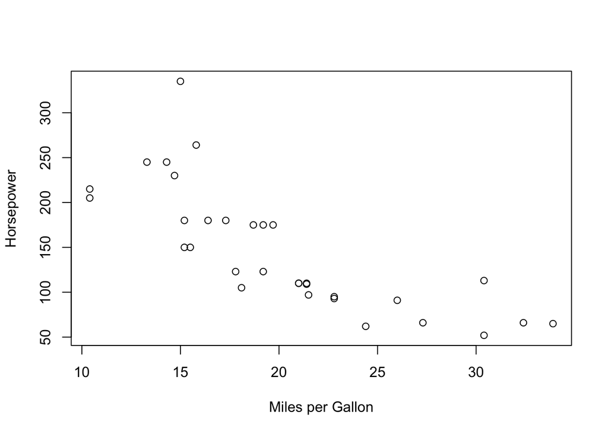

```r
plot(mtcars$mpg, mtcars$hp, xlab = "Miles per Gallon", ylab = "Horsepower")
```

However, more complex analyses and plots require the data to be in "long" format, where each row of the data frame is an observation, with a "measurement" column to describe the type of observation made. Each car would then have multiple rows, corresponding to the different measured properties.

One way to do the conversion uses the `tidyr` package:

```r
library(tidyr)
mtcars_long <- gather(mtcars, variable, measurement, mpg:carb)
mtcars_long$variable <- as.factor(mtcars_long$variable)

summary(mtcars_long)
```

```
##                 model     transmission_type    variable
##  AMC Javelin       : 11   automatic:209     am     : 32
##  Cadillac Fleetwood: 11   manual   :143     carb   : 32
##  Camaro Z28        : 11                     cyl    : 32
##  Chrysler Imperial : 11                     disp   : 32
##  Datsun 710        : 11                     drat   : 32
##  Dodge Challenger  : 11                     gear   : 32
##  (Other)           :286                     (Other):160
##   measurement
##  Min.   :  0.000
##  1st Qu.:  2.429
##  Median :  4.000
##  Mean   : 39.608
##  3rd Qu.: 18.975
##  Max.   :472.000
##
```

And which also allows us to go in the other direction:

```r
mtcars_wide <- spread(mtcars_long, variable, measurement)
summary(mtcars_wide)
```

```
##                 model    transmission_type       am
##  AMC Javelin       : 1   automatic:19      Min.   :0.0000
##  Cadillac Fleetwood: 1   manual   :13      1st Qu.:0.0000
##  Camaro Z28        : 1                     Median :0.0000
##  Chrysler Imperial : 1                     Mean   :0.4062
##  Datsun 710        : 1                     3rd Qu.:1.0000
##  Dodge Challenger  : 1                     Max.   :1.0000
##  (Other)           :26
##       carb            cyl             disp            drat
##  Min.   :1.000   Min.   :4.000   Min.   : 71.1   Min.   :2.760
##  1st Qu.:2.000   1st Qu.:4.000   1st Qu.:120.8   1st Qu.:3.080
##  Median :2.000   Median :6.000   Median :196.3   Median :3.695
##  Mean   :2.812   Mean   :6.188   Mean   :230.7   Mean   :3.597
##  3rd Qu.:4.000   3rd Qu.:8.000   3rd Qu.:326.0   3rd Qu.:3.920
##  Max.   :8.000   Max.   :8.000   Max.   :472.0   Max.   :4.930
##
##       gear             hp             mpg             qsec
##  Min.   :3.000   Min.   : 52.0   Min.   :10.40   Min.   :14.50
##  1st Qu.:3.000   1st Qu.: 96.5   1st Qu.:15.43   1st Qu.:16.89
##  Median :4.000   Median :123.0   Median :19.20   Median :17.71
##  Mean   :3.688   Mean   :146.7   Mean   :20.09   Mean   :17.85
##  3rd Qu.:4.000   3rd Qu.:180.0   3rd Qu.:22.80   3rd Qu.:18.90
##  Max.   :5.000   Max.   :335.0   Max.   :33.90   Max.   :22.90
##
##        vs               wt
##  Min.   :0.0000   Min.   :1.513
##  1st Qu.:0.0000   1st Qu.:2.581
##  Median :0.0000   Median :3.325
##  Mean   :0.4375   Mean   :3.217
##  3rd Qu.:1.0000   3rd Qu.:3.610
##  Max.   :1.0000   Max.   :5.424
##
```

# 6 Resources

## 6.1 Additional Information

- https://rawgit.com/kevinushey/2017-rstudio-conf/master/slides.html#1

  RStudio tips and tricks
- http://rmarkdown.rstudio.com/

  R Markdown basics
- http://rmarkdown.rstudio.com/authoring_bibliographies_and_citations.html

  Bibliographies and citations in R Markdown
- https://slides.yihui.name/2017-rstudio-conf-rmarkdown-Yihui-Xie.html#1

  Advanced R Markdown
- http://www.cookbook-r.com/

  Sample code for various tasks in R
- https://www.rstudio.com/resources/cheatsheets/

  Cheatsheets (for various topics in R and RStudio)